# Factor analysis cellcycleR

Kushal K Dey

February 3, 2016

## Overview

Cell cycle analysis is a complicated endeavor because there are many different types of genes that behave in their own distinctive ways. Our interest in cell cycle analysis has been mainly centered around extracting potential top genes that contain information on cell-cycle phasing and also to extract the cell phases on the cell cycle. The cell phase ordering is heavily dependent on the set of genes we choose initially. On the full set of genes, it seems the ribosomal genes tend to dominate the patterns. In this script, we consider two simulation scenarios of cell cycle expression analysis and perform sparse factor analysis to see if we are picking the right groups of genes or not as factors.

## Simulation Expt 1

```r
library(PMA)
library(cellcycleR)
library(wavethresh)
G <- 100;
num_cells <- 256;
amp_genes1 <- c(rep(8, G/2), rep(6, G/4), rep(0,G/4));
phi_genes1 <- rep(c(2,5,4,2), each=G/4);
sigma_genes1 <- rchisq(G, 2);
cell_times_sim <- sort(sample(seq(0,2*pi, 2*pi/(num_cells-1)), num_cells, replace=FALSE));
cycle_data <- t(sim_sinusoidal_cycle(G, amp_genes1, phi_genes1, sigma_genes1, cell_times_sim));

celltime_levels <- 256;

sample_reorder <- sample(1:num_cells,num_cells, replace=FALSE);
cell_times_reorder <- cell_times_sim[sample_reorder];
cycle_data_reorder <- cycle_data[,sample_reorder];
```

The cyclical pattern for $2$ nd gene

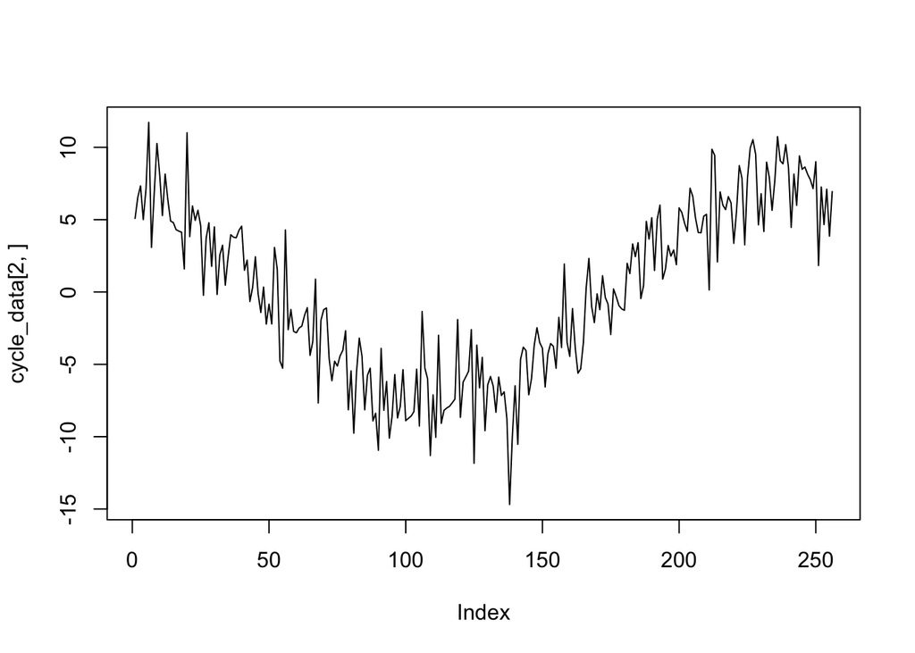

```r
plot(cycle_data[2,], type="l");
```

The pattern for $52$ nd gene.

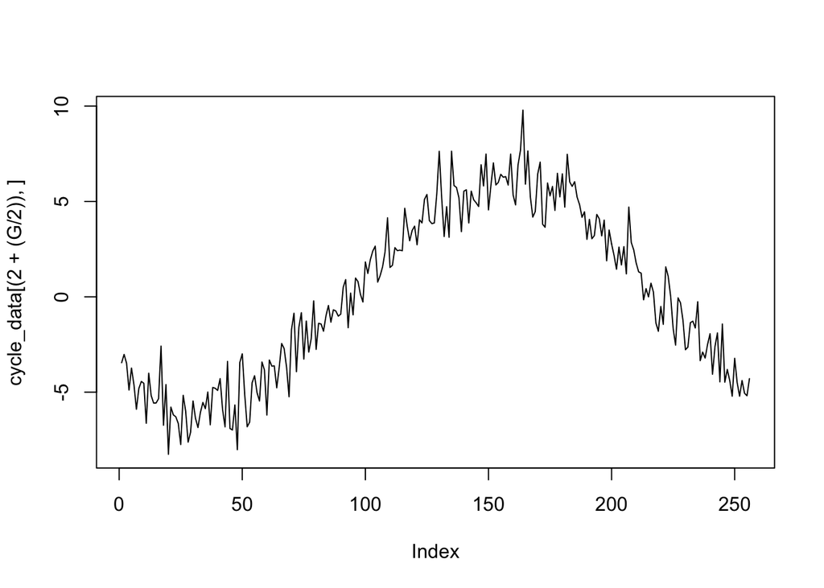

```r
plot(cycle_data[(2+(G/2)),], type="l")
```

### Factor analysis (K=2)

We apply factor analysis (K=2).

```r
library(PMA)
pmd1 <- PMD(cycle_data_reorder, type="standard", K=2, niter=50);
```

```
## 123456789101112131415161718192021222324252627282930313233343536373839404142
## 12345678910111213141516171819202122232425262728293031
```

We plot the barplot of the factor loadings, colors representing the two factors.

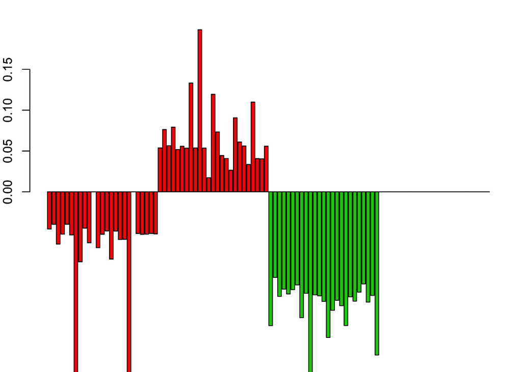

```r
pos_u <- apply(pmd1$u, c(1,2), function(x) return (max(x,0)))
neg_u <- apply(pmd1$u, c(1,2), function(x) return (min(x,0)))

par(mar=c(12,2,2,1))
barplot(t(pos_u), col=2:5)
barplot(t(neg_u), col=2:5, add=TRUE)
```

### Factor analysis (K=4)

We apply factor analysis (K=4).

```r
library(PMA)
pmd1 <- PMD(cycle_data_reorder, type="standard", K=4, niter=50);
```

```
## 123456789101112131415161718192021222324252627282930313233343536373839404142
## 12345678910111213141516171819202122232425262728293031
## 12345678910111213141516171819202122232425262728293031323334353637383940414243444546
## 123456789101112131415161718192021222324252627282930
```

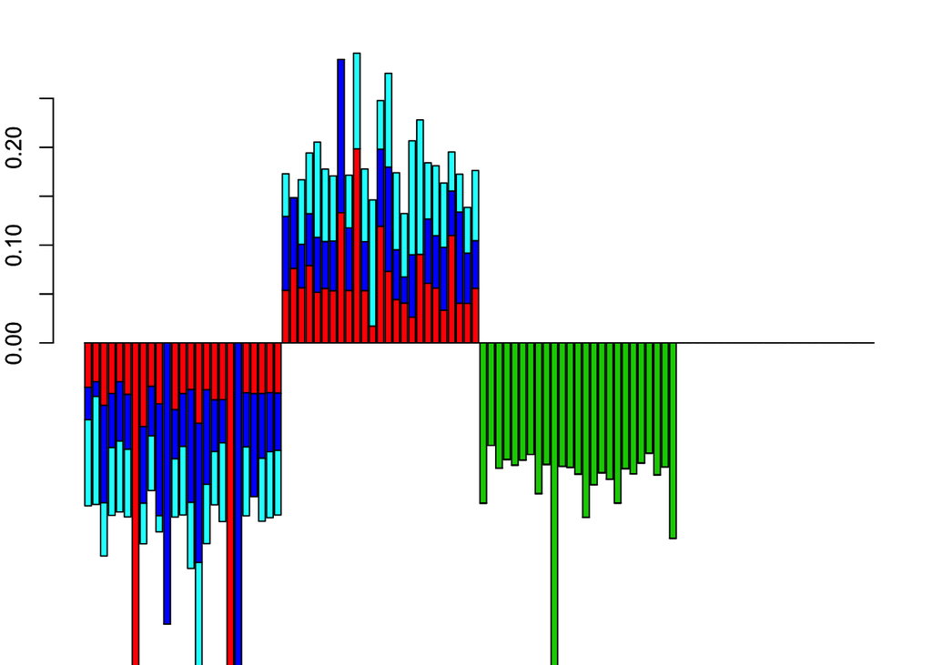

```r
pos_u <- apply(pmd1$u, c(1,2), function(x) return (max(x,0)))
neg_u <- apply(pmd1$u, c(1,2), function(x) return (min(x,0)))

par(mar=c(12,2,2,1))
barplot(t(pos_u), col=2:5)
barplot(t(neg_u), col=2:5, add=TRUE)
```

Note that the last $1/4$ th genes do not show any loadings because they have amplitudes $0$ and mainly contribute to noise. However it does seem that the phases of the genes are determining the groups which is encouraging and may mean that the cell cycle genes which have phases with peaks at G1 or S phase specifically will form a factor of their own.

## Simulation Expt 2

In this simulation scenario, we consider genes which have high expression at particular cell states as well (as in ribosomal genes) and we check how that impacts the cell order.

```r
library(PMA)
library(cellcycleR)
library(wavethresh)
G <- 100;
num_cells <- 256;
amp_genes1 <- c(rep(8, G/2), rep(6, G/4), rep(0,G/4));
phi_genes1 <- rep(c(2,5,4,2), each=G/4);
sigma_genes1 <- rchisq(G, 2);
cell_times_sim <- sort(sample(seq(0,2*pi, 2*pi/(num_cells-1)), num_cells, replace=FALSE));
cycle_data <- t(sim_sinusoidal_cycle(G, amp_genes1, phi_genes1, sigma_genes1, cell_times_sim));
```

```r
n_states <- 10;
n_ribo <- 10;
cell_states <- sapply(1:n_states, function(s) floor((s*length(cell_times_sim))/n_states));
for(m in 1:n_states){
  for(n in 1:n_ribo){
    cycle_data[n,cell_states[m]] <- rnorm(1,20,1);
  }
}
```

```r
celltime_levels <- 256;

sample_reorder <- sample(1:num_cells,num_cells, replace=FALSE);
cell_times_reorder <- cell_times_sim[sample_reorder];
cycle_data_reorder <- cycle_data[,sample_reorder];
```

The cyclical pattern for $2$ nd gene

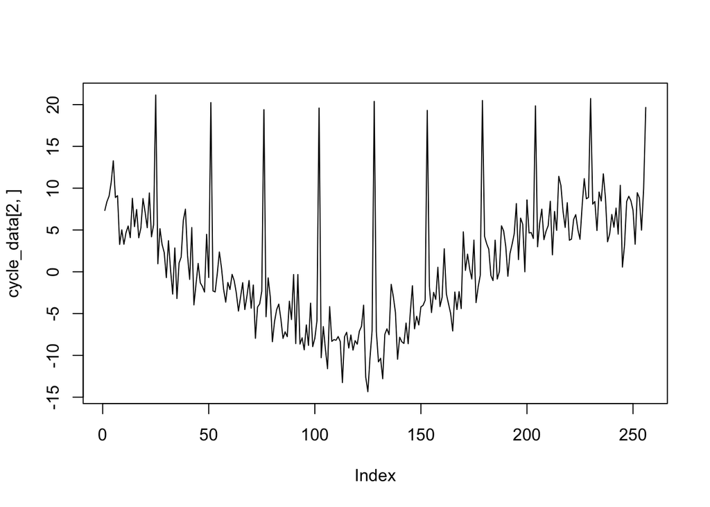

```r
plot(cycle_data[2,], type="l");
```

The pattern for $52$ nd gene.

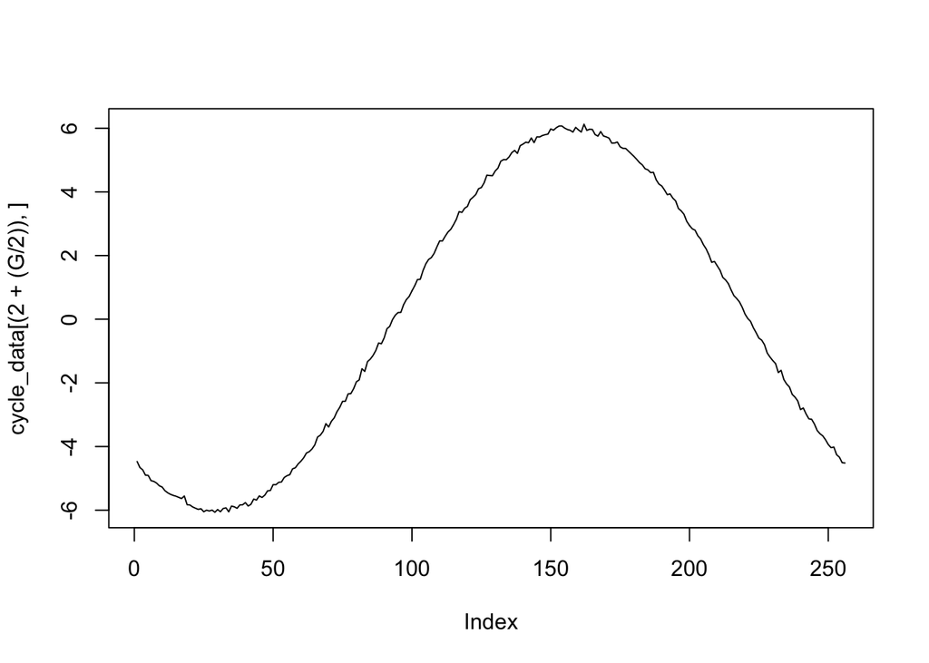

```r
plot(cycle_data[(2+(G/2)),], type="l")
```

### Factor analysis (K=2)

We apply factor analysis (K=2).

```r
library(PMA)
pmd1 <- PMD(cycle_data_reorder, type="standard", K=2, niter=50);
```

```
## 123456789101112131415161718
## 1234567891011121314151617181920212223242526272829303132333435363738394041424344454647484950
```

We plot the barplot of the factor loadings, colors representing the two factors.

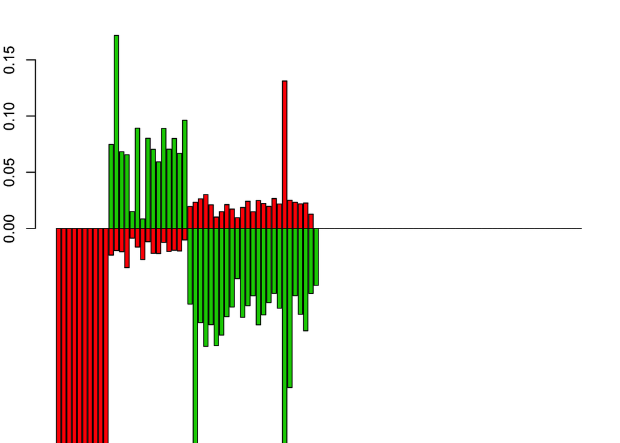

```r
pos_u <- apply(pmd1$u, c(1,2), function(x) return (max(x,0)))
neg_u <- apply(pmd1$u, c(1,2), function(x) return (min(x,0)))

par(mar=c(12,2,2,1))
barplot(t(pos_u), col=2:5)
barplot(t(neg_u), col=2:5, add=TRUE)
```

### Factor analysis (K=4)

We apply factor analysis (K=4).

```r
library(PMA)
pmd1 <- PMD(cycle_data_reorder, type="standard", K=4, niter=50);
```

```
## 123456789101112131415161718
## 1234567891011121314151617181920212223242526272829303132333435363738394041424344454647484950
## 1234567891011121314151617181920212223242526272829303132333435363738394041424344454647484950
## 1234567891011121314151617181920
```

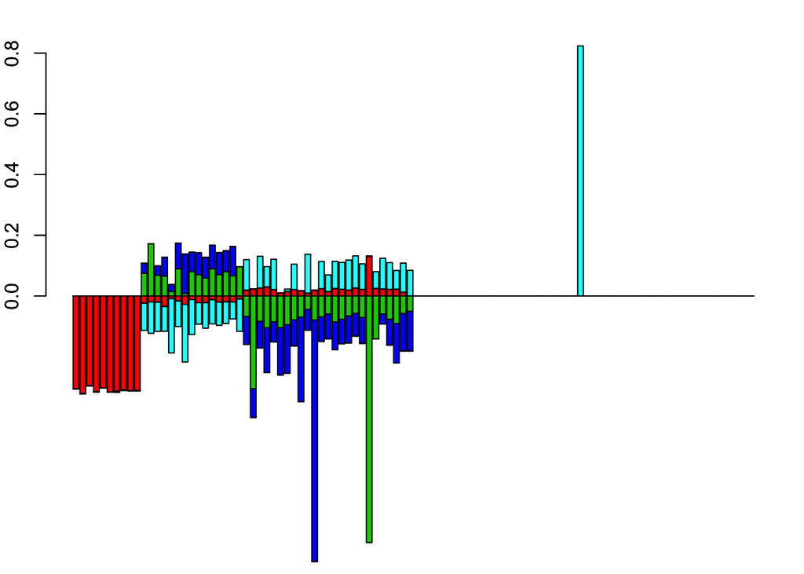

```r
pos_u <- apply(pmd1$u, c(1,2), function(x) return (max(x,0)))
neg_u <- apply(pmd1$u, c(1,2), function(x) return (min(x,0)))

par(mar=c(12,2,2,1))
barplot(t(pos_u), col=2:5)
barplot(t(neg_u), col=2:5, add=TRUE)
```